# Murine Brain Tumor CAR-T scRNA-seq Analysis Report - re-sequenced

# Summary of methods used

## Main lineages processing & annotation

- Ran SoupX and DoubletFinder algorithms to correct for ambient RNA and remove doublets, respectively
- Standard Seurat QC, processing and integration workflow for 12 10X v2 flex libraries
- Annotated main cell lineages by combining automatic algorithm (SingleR) and manual marker inspection
- Deliverables (main_dataset/)
  - UMAP plots: cart_umap_lineage_annotations.png & cart_umap_clusters.png

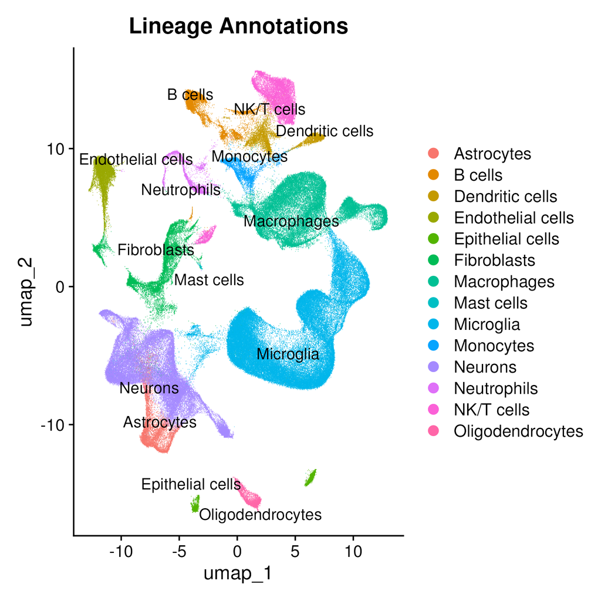

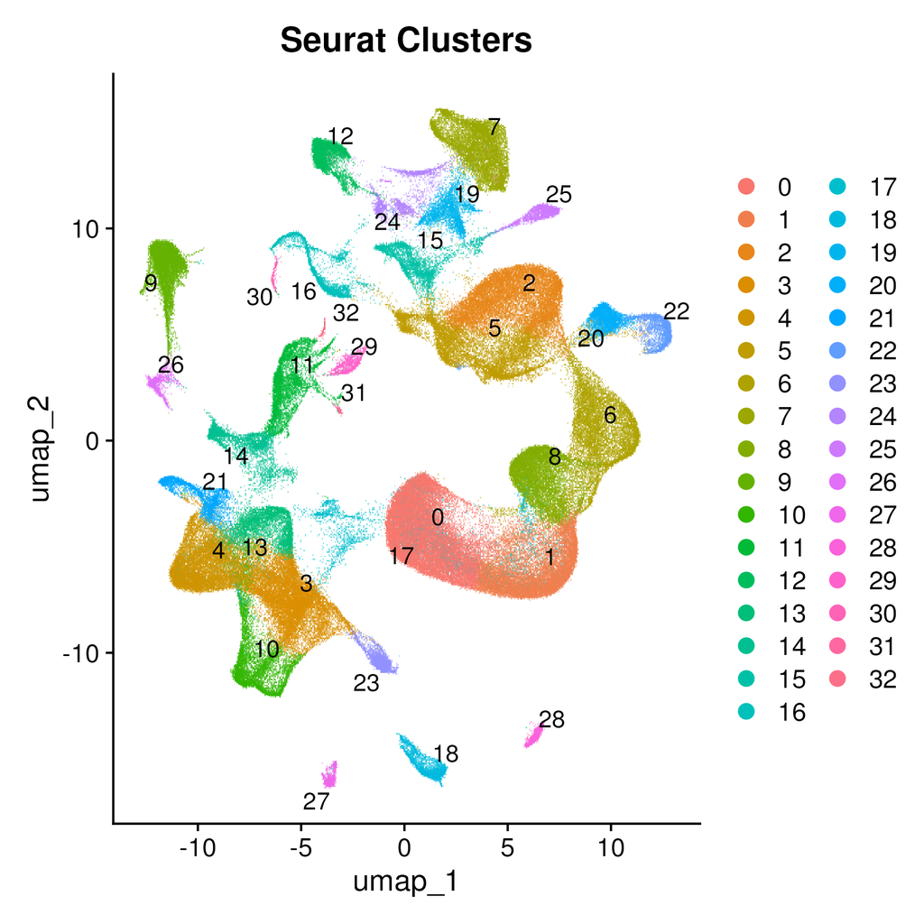

  - Marker gene heatmap: cart_heatmap_top_lineage_markers.pdf

[figure not shown]

  - Marker gene lists: cart_cluster_markers.csv & cart_lineage_markers.csv
  - Lineage dot plot: cart_dotplot_lineage_proportions.png

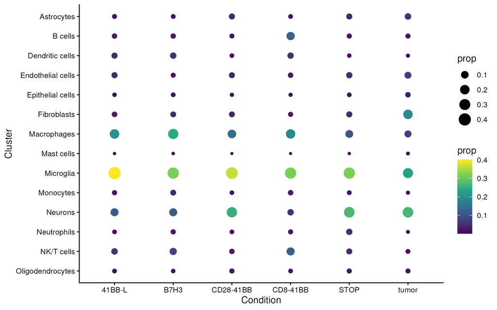

## Myeloid heterogeneity

- Subclustering of macrophage, microglia, and monocyte clusters
- Refined into interpretable functional myeloid subtypes
  - Homeostatic Microglia
  - Stress-Response Microglia
  - Early Activated Microglia
  - Inflammatory Activated Microglia
  - TAM-like Phagocytic Microglia
  - Angiogenic Tumor-Associated Macrophages (TAMs)
  - Antigen-Presenting TAMs
  - Inflammatory TAMs
  - Lipid-associated TAMs
  - Perivascular Macrophages
  - Perivascular Macrophages (Chemokine producing)
  - Antigen-Presenting Monocytes
  - Inflammatory Monocytes
  - cDC1 (contamination in subclustering)
- Compositional analysis of myeloid subtypes across CAR-T design conditions using sccomp package
- Gene sets enrichment analysis using AUCell and fgsea packages, utilizing the following MSigDB gene sets:
  - Hallmark
  - C5: Ontology
  - C7: Immunology
- Deliverables (myeloid_subtypes)
  - UMAP plots: myeloid_subtypes_umap.png & myeloid_subtypes_by_condition_umap.png

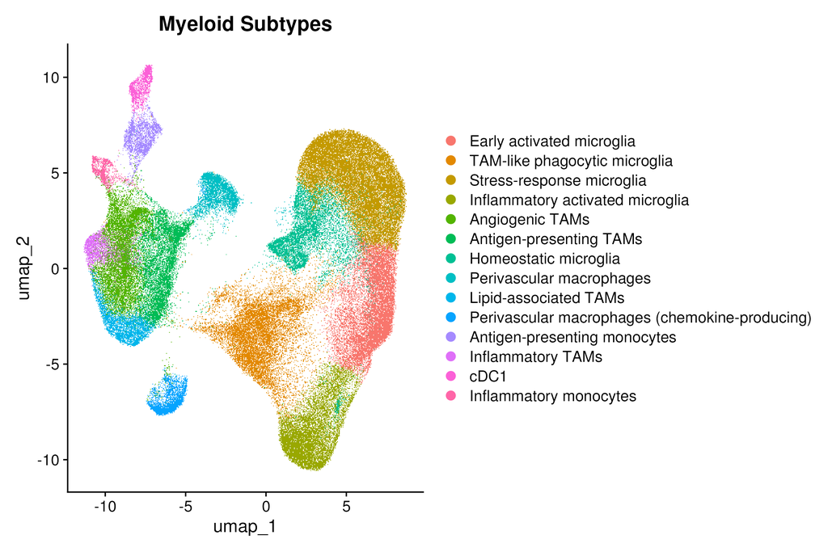

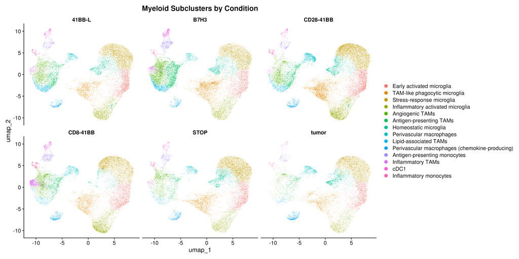

  - Marker gene heatmap: myeloid_subtype_heatmap_top_markers.pdf

[figure not shown]

  - Marker gene lists: myeloid_subcluster_markers.csv & myeloid_subtype_markers.csv
  - sccomp results
    - myeloid_subtype_composition_sccomp.png
    - myeloid_subtype_proportions_barplot.png
    - myeloid_subtype_proportions_dotplot.png

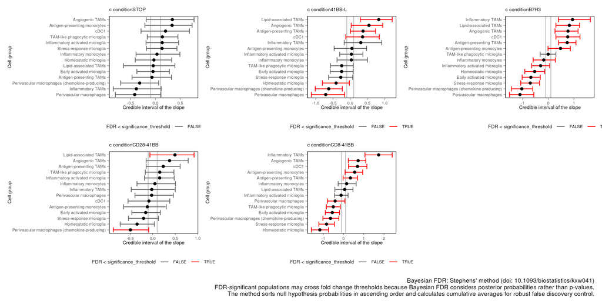

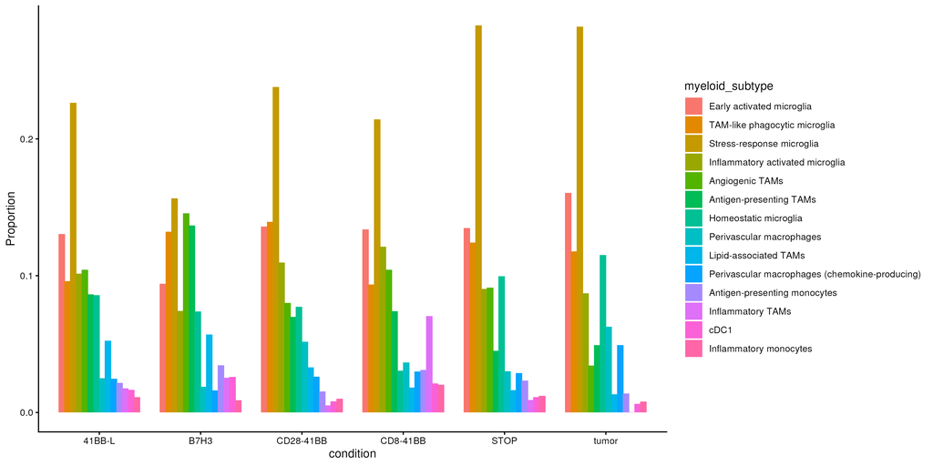

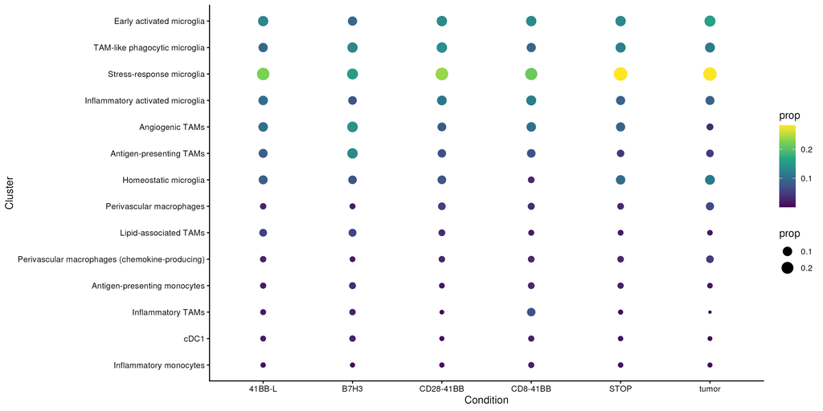

  - AUCell results: myeloid_subtype_hallmark_auc_heatmap.pdf

[figure not shown]

  - GSEA results
    - myeloid_subtype_hallmark_gsea_results.csv
    - myeloid_subtype_c5_gsea_results.csv
    - myeloid_subtype_c7_gsea_results.csv